# phyloseq_H7_DESeq2 with phyloseq

wentao

2019/8/23

# phyloseq中的DESeq2 差异分析

这也是phyloseq中推荐的差异分析方法：

DEsep在phyloseq包中有正式的扩展和相应的介绍。phyloseq_to_deseq2函数在导入phyloseq包时就可以使用了，无需额外加载。

> DESeq2 has an official extension within the phyloseq package and an accompanying vignette. The vignette has been copied/included here for continuity, and as you can see, phyloseq_to_deseq2 does not need to be defined before using it because it is already available when you load phyloseq.

## 关于引用

**Citations**

如果你觉得下面的教程帮助到了你，请参考一下的引用。

### 不同丰度的微生物数据

**Differential Abundance for Microbiome Data**

> McMurdie and Holmes (2014) Waste Not, Want Not: Why Rarefying Microbiome Data is Inadmissible. PLoS Computational Biology in press

### phyloseq

> McMurdie and Holmes (2013) phyloseq: An R Package for Reproducible Interactive Analysis and Graphics of Microbiome Census Data. PLoS ONE. 8(4):e61217

### DESeq2

> Love MI, Huber W, Anders S (2014) Moderated estimation of fold change and dispersion for RNA-seq data with DESeq2. Genome Biology 15(12): 550

准备数据： 在本例子中我们使用的数据是研究直肠癌症公开的数据。

> Background on the data In this example I use the publicly available data from a study on colorectal cancer: Genomic analysis identifies association of Fusobacterium with colorectal carcinoma. Kostic, A. D., Gevers, D., Pedamallu, C. S., Michaud, M., Duke, F., Earl, A. M., et al. (2012). Genome research, 22(2), 292-298.

补充的是，这项研究是在基因组研究之前发表的。这里还有另外一份相似的研究（长期重复观测结果）:Fusobacterium nucleatum感染结肠癌中很常见，如果你有这个案例有兴趣。但是我们并没有采用这份数据，处于多个考虑我们最终使用的是 microbio.me/qiime 服务器上的第一份数据

Qiita中的项目编号：1457；

研究摘要：

> As a side-note, this work was published ahead of print in Genome Research alongside a highly-related article from a separate group of researchers (long-live reproducible observations!): Fusobacterium nucleatum infection is prevalent in human colorectal carcinoma. In case you are interested. For the purposes of example, however, we will stick to the data from the former study, with data available at the microbio.me/qiime server.

> Study ID: 1457

> Project Name: Kostic_colorectal_cancer_fusobacterium

研究摘要：

> Study Abstract: The tumor microenvironment of colorectal carcinoma is a complex community of genomically altered cancer cells, nonneoplastic cells, and a diverse collection of microorganisms. Each of these components may contribute to carcino genesis; however, the role of the microbiota is the least well understood. We have characterized the composition of the microbiota in colorectal carcinoma using whole genome sequences from nine tumor/normal pairs. Fusobacterium sequences were enriched in carcinomas, confirmed by quantitative PCR and 16S rDNA sequence analysis of 95 carcinoma/normal DNA pairs, while the Bacteroidetes and Firmicutes phyla were depleted in tumors. Fusobacteria were also visualized within colorectal tumors using FISH. These findings reveal alterations in the colorectal cancer microbiota; however, the precise role of Fusobacteria in colorectal carcinoma pathogenesis requires further investigation.

### 导入数据转化为DESeq2

**Import data with phyloseq, convert to DESeq2**

```r
library("phyloseq"); packageVersion("phyloseq")
```

```
## [1] '1.28.0'
```

导入数据

```r
filepath = system.file("extdata", "study_1457_split_library_seqs_and_mapping.zip", package="phyloseq")
kostic = microbio_me_qiime(filepath)
```

```
## Found biom-format file, now parsing it...
## Done parsing biom...
## Importing Sample Metdadata from mapping file...
## Merging the imported objects...
## Successfully merged, phyloseq-class created.
##  Returning...
```

```r
kostic
```

```
## phyloseq-class experiment-level object
## otu_table()   OTU Table:         [ 2505 taxa and 190 samples ]
## sample_data() Sample Data:       [ 190 samples by 71 sample variables ]
## tax_table()   Taxonomy Table:    [ 2505 taxa by 7 taxonomic ranks ]
```

#### 可选，本次不需要

在这个例子中，我们使用DIAGNOSIS作为分组变量。这项研究的重点在于区分发病和健康的微生物群落，所以挑选这个分组变量是有意义的。对于我们自己的数据，可以进行更复杂的分组，设置是多个分组，如果这对你的试验有重要意义的话。如果当前表格中并没有可以代表你样品分组的变量列，可能你还需要添加新的分组。详细参见DESeq2主页。

下面使我们使用的数据kostic，我们简要展示分组文件信息。

> In this example I’m using the major sample covariate, DIAGNOSIS, as the study design factor. The focus of this study was to compare the microbiomes of pairs of healthy and cancerous tissues, so this makes sense. Your study could have a more complex or nested design, and you should think carefully about the study design formula, because this is critical to the test results and their meaning. You might even need to define a new factor if none of the variables in your current table appropriately represent your study’s design. See the DESeq2 home page for more details.

> Here is the summary of the data variable kostic that we are about to use, as well as the first few entries of the DIAGNOSIS factor.

subset_samplesh函数，对样品取子集，去除DIAGNOSIS为Nona的样本。

> Unfortunately, the diagnosis variable has a third placeholder class indicating that no diagnosis was given (“None”). For the purposes of testing, these samples will be removed.

```r
kostic = subset_samples(kostic, DIAGNOSIS != "None")
kostic
```

```
## phyloseq-class experiment-level object
## otu_table()   OTU Table:         [ 2505 taxa and 185 samples ]
## sample_data() Sample Data:       [ 185 samples by 71 sample variables ]
## tax_table()   Taxonomy Table:    [ 2505 taxa by 7 taxonomic ranks ]
```

```r
head(sample_data(kostic)$DIAGNOSIS, 25)
```

```
##  [1] Healthy Tumor   Tumor   Healthy Healthy Healthy Tumor   Healthy
##  [9] Healthy Healthy Healthy Healthy Healthy Healthy Healthy Tumor
## [17] Healthy Healthy Healthy Healthy Healthy Tumor   Tumor   Tumor
## [25] Healthy
## Levels: Healthy Tumor
```

### 导入DESeq2包

```r
library("DESeq2")
packageVersion("DESeq2")
```

```
## [1] '1.22.2'
```

### 这个地方官网教程出现错误

github上讨论过这个问题，地址：https://github.com/joey711/phyloseq/issues/387

下面这两行试剂上就完成了DESeq2的全部工作； phyloseq_to_deseq2函数可以将phyloseq格式的微生物组数据转化为DESeq2需要的格式，然后DESea完成剩下的差异分析工作。在本例子中我们使用的默认的参数进行分析，但是我们实际上可以修改。

很遗憾，作者这里d额数据似乎需要转化，由于log转化出现问题，所以我们做了相应的代码修改。（具体就这个问题的讨论在githu上面的地址，我们也会在教程结束后就主要的报错及其问题总结一份教程。）

> The following two lines actually do all the complicated DESeq2 work. The function phyloseq_to_deseq2 converts your phyloseq-format microbiome data into a DESeqDataSet with dispersions estimated, using the experimental design formula, also shown (the ~DIAGNOSIS term). The DESeq function does the rest of the testing, in this case with default testing framework, but you can actually use alternatives.

### 更正代码

这里将讨论的结果更换源代码，正确操作。

```r
gm_mean = function(x, na.rm=TRUE){
  exp(sum(log(x[x > 0]), na.rm=na.rm) / length(x))
}


diagdds = phyloseq_to_deseq2(kostic, ~ DIAGNOSIS)
# calculate geometric means prior to estimate size factors
gm_mean = function(x, na.rm=TRUE){
  exp(sum(log(x[x > 0]), na.rm=na.rm) / length(x))
}
geoMeans = apply(counts(diagdds), 1, gm_mean)
diagdds = estimateSizeFactors(diagdds, geoMeans = geoMeans)
diagdds = DESeq(diagdds, fitType="local")
```

```
## -- replacing outliers and refitting for 411 genes
## -- DESeq argument 'minReplicatesForReplace' = 7
## -- original counts are preserved in counts(dds)
```

```r
diagdds = DESeq(diagdds, test="Wald", fitType="parametric")
```

```
## found already estimated dispersions, replacing these
```

```
## -- replacing outliers and refitting for 411 genes
## -- DESeq argument 'minReplicatesForReplace' = 7
## -- original counts are preserved in counts(dds)
```

m默认的多重比较实用的是Benjamini-Hochberg方法。

> Note: The default multiple-inference correction is Benjamini-Hochberg, and occurs within the DESeq function.

### 提取差异分析结果

**Investigate test results table**

```r
res = results(diagdds, cooksCutoff = FALSE)
alpha = 0.01
sigtab = res[which(res$padj < alpha), ]
sigtab = cbind(as(sigtab, "data.frame"), as(tax_table(kostic)[rownames(sigtab), ], "matrix"))
head(sigtab)
```

```
##          baseMean log2FoldChange     lfcSE      stat       pvalue
## 469893   1.462675       3.260123 0.7537185  4.325385 1.522657e-05
## 72853   26.976551      -1.607239 0.3357813 -4.786564 1.696608e-06
## 307981   3.042124       2.159437 0.4846190  4.455948 8.352326e-06
## 64396  170.782244       2.189111 0.4301700  5.088943 3.600644e-07
##                padj  Kingdom         Phylum                 Class
## 469893 0.0094404714 Bacteria Proteobacteria Epsilonproteobacteria
## 72853  0.0021037940 Bacteria     Firmicutes            Clostridia
## 307981 0.0069045897 Bacteria Proteobacteria   Gammaproteobacteria
## 64396  0.0008929597 Bacteria   Fusobacteria  Fusobacteria (class)
##                    Order             Family            Genus
## 469893 Campylobacterales Campylobacteraceae    Campylobacter
## 72853      Clostridiales    Ruminococcaceae Faecalibacterium
## 307981 Enterobacteriales Enterobacteriaceae       Klebsiella
## 64396    Fusobacteriales   Fusobacteriaceae    Fusobacterium
##                     Species
## 469893 Campylobacter rectus
## 72853                  <NA>
## 307981                 <NA>
## 64396                  <NA>
```

```r
dim(sigtab)
```

```
## [1]  4 13
```

### 仅仅有四个差异物种，这里使用差异倍数出图

让我们看看在两个组织中显著性差异的OTU。使用ggplot出图

> Let’s look at the OTUs that were significantly different between the two tissues. The following makes a nice ggplot2 summary of the results.

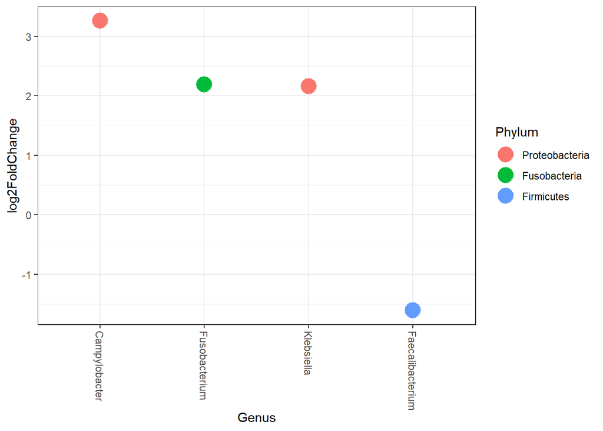

```r
library("ggplot2")
theme_set(theme_bw())
scale_fill_discrete <- function(palname = "Set1", ...) {
    scale_fill_brewer(palette = palname, ...)
}
# Phylum order
x = tapply(sigtab$log2FoldChange, sigtab$Phylum, function(x) max(x))
x = sort(x, TRUE)
sigtab$Phylum = factor(as.character(sigtab$Phylum), levels=names(x))
# Genus order
x = tapply(sigtab$log2FoldChange, sigtab$Genus, function(x) max(x))
x = sort(x, TRUE)
sigtab$Genus = factor(as.character(sigtab$Genus), levels=names(x))
ggplot(sigtab, aes(x=Genus, y=log2FoldChange, color=Phylum)) + geom_point(size=6) +
  theme(axis.text.x = element_text(angle = -90, hjust = 0, vjust=0.5))
```

### reference

http://joey711.github.io/phyloseq-extensions/DESeq2.html